# Project: Investigate a Dataset (Medical Appointments No Shows)

- Introduction
- Questions
- Data Wrangling
- Exploratory Data Analysis
- Conclusions

## Introduction

> This project deals in the investigation of appoinment records for Brasil public hospitals. The dataset includes some attributes of patients like,the patient age,gender, etc. The analysis of this project is based on the ivestigation of factors affecting patients attendance to their appointments.

# Questions

1. What is the age distribution for patients who showed up and patients who didn't by their genders?
2. What is the gender distribution for patients who showed up and patients who didn't?
3. Does Neighbourhood affect patients?
4. What factors are important to know in order to predict if a patient will show up for their scheduled appointment?
5. What days are being scheduled the most?
6. Does age affect the number of attendance?

```python
# Importing the important librariesy
import pandas as pd
import numpy as np
from matplotlib import pyplot as plt
import seaborn as sns
%matplotlib inline
```

## Data Wrangling

```python
# Loading the data and printing out the first five rows.
data = pd.read_csv(r"C:\Users\Chinedu\Documents\Data Analytics\KaggleV2-May-2016.csv")
data.head()
```

|  | PatientId | AppointmentID | Gender | ScheduledDay | AppointmentDay | Age | Neighbourhood | Scholarship | Hipertension | Diabetes | Alcoholism | Handcap | SMS_received | No-show |
| --- | --- | --- | --- | --- | --- | --- | --- | --- | --- | --- | --- | --- | --- | --- |
| 0 | 2.987250e+13 | 5642903 | F | 2016-04-29T18:38:08Z | 2016-04-29T00:00:00Z | 62 | JARDIM DA PENHA | 0 | 1 | 0 | 0 | 0 | 0 | No |
| 1 | 5.589978e+14 | 5642503 | M | 2016-04-29T16:08:27Z | 2016-04-29T00:00:00Z | 56 | JARDIM DA PENHA | 0 | 0 | 0 | 0 | 0 | 0 | No |
| 2 | 4.262962e+12 | 5642549 | F | 2016-04-29T16:19:04Z | 2016-04-29T00:00:00Z | 62 | MATA DA PRAIA | 0 | 0 | 0 | 0 | 0 | 0 | No |
| 3 | 8.679512e+11 | 5642828 | F | 2016-04-29T17:29:31Z | 2016-04-29T00:00:00Z | 8 | PONTAL DE CAMBURI | 0 | 0 | 0 | 0 | 0 | 0 | No |
| 4 | 8.841186e+12 | 5642494 | F | 2016-04-29T16:07:23Z | 2016-04-29T00:00:00Z | 56 | JARDIM DA PENHA | 0 | 1 | 1 | 0 | 0 | 0 | No |

```python
# Knowing the basic informations about the data
data.info()
```

```
<class 'pandas.core.frame.DataFrame'>
RangeIndex: 110527 entries, 0 to 110526
Data columns (total 14 columns):
 #   Column          Non-Null Count   Dtype
---  ------          --------------   -----
 0   PatientId       110527 non-null  float64
 1   AppointmentID   110527 non-null  int64
 2   Gender          110527 non-null  object
 3   ScheduledDay    110527 non-null  object
 4   AppointmentDay  110527 non-null  object
 5   Age             110527 non-null  int64
 6   Neighbourhood   110527 non-null  object
 7   Scholarship     110527 non-null  int64
 8   Hipertension    110527 non-null  int64
 9   Diabetes        110527 non-null  int64
 10  Alcoholism      110527 non-null  int64
 11  Handcap         110527 non-null  int64
 12  SMS_received    110527 non-null  int64
 13  No-show         110527 non-null  object
dtypes: float64(1), int64(8), object(5)
memory usage: 11.8+ MB
```

```python
data.describe()
```

|  | PatientId | AppointmentID | Age | Scholarship | Hipertension | Diabetes | Alcoholism | Handcap | SMS_received |
| --- | --- | --- | --- | --- | --- | --- | --- | --- | --- |
| count | 1.105270e+05 | 1.105270e+05 | 110527.000000 | 110527.000000 | 110527.000000 | 110527.000000 | 110527.000000 | 110527.000000 | 110527.000000 |
| mean | 1.474963e+14 | 5.675305e+06 | 37.088874 | 0.098266 | 0.197246 | 0.071865 | 0.030400 | 0.022248 | 0.321026 |
| std | 2.560949e+14 | 7.129575e+04 | 23.110205 | 0.297675 | 0.397921 | 0.258265 | 0.171686 | 0.161543 | 0.466873 |
| min | 3.921784e+04 | 5.030230e+06 | -1.000000 | 0.000000 | 0.000000 | 0.000000 | 0.000000 | 0.000000 | 0.000000 |
| 25% | 4.172614e+12 | 5.640286e+06 | 18.000000 | 0.000000 | 0.000000 | 0.000000 | 0.000000 | 0.000000 | 0.000000 |
| 50% | 3.173184e+13 | 5.680573e+06 | 37.000000 | 0.000000 | 0.000000 | 0.000000 | 0.000000 | 0.000000 | 0.000000 |
| 75% | 9.439172e+13 | 5.725524e+06 | 55.000000 | 0.000000 | 0.000000 | 0.000000 | 0.000000 | 0.000000 | 1.000000 |
| max | 9.999816e+14 | 5.790484e+06 | 115.000000 | 1.000000 | 1.000000 | 1.000000 | 1.000000 | 4.000000 | 1.000000 |

```python
# Checking to know the number of rows and columns
data.shape
```

```
(110527, 14)
```

```python
# Checking to see if any row was repeated
# No duplicated row
data.duplicated().sum()
```

```
0
```

```python
# Confirming if the data has any null values
# No null row
data.isnull().sum().sum()
```

```
0
```

```python
# Knowing the data types
data.dtypes
```

```
PatientId         float64
AppointmentID       int64
Gender             object
ScheduledDay       object
AppointmentDay     object
Age                 int64
Neighbourhood      object
Scholarship         int64
Hipertension        int64
Diabetes            int64
Alcoholism          int64
Handcap             int64
SMS_received        int64
No-show            object
dtype: object
```

# Observation

From the overview;

1. The data has no null values(NaNs).
2. The data has no duplicated rows.
3. The Scheduled_Day and Appointment_Day are in string format instead of date and time format
4. The data has a age that is less than one(1) in the description.

# # Data Cleaning

```python
# Changing the name of some columns
data.rename(columns = {"PatientId": "Patient_ID", "AppointmentID":"Appointment_ID", "ScheduledDay":"Scheduled_Day",
       "AppointmentDay":"Appointment_Day","Hipertension" :"Hypertension", "Handcap" : "Handicap", "No-show":"No_show"}, inplace = True)
data.head()
```

|  | Patient_ID | Appointment_ID | Gender | Scheduled_Day | Appointment_Day | Age | Neighbourhood | Scholarship | Hypertension | Diabetes | Alcoholism | Handicap | SMS_received | No_show |
| --- | --- | --- | --- | --- | --- | --- | --- | --- | --- | --- | --- | --- | --- | --- |
| 0 | 2.987250e+13 | 5642903 | F | 2016-04-29T18:38:08Z | 2016-04-29T00:00:00Z | 62 | JARDIM DA PENHA | 0 | 1 | 0 | 0 | 0 | 0 | No |
| 1 | 5.589978e+14 | 5642503 | M | 2016-04-29T16:08:27Z | 2016-04-29T00:00:00Z | 56 | JARDIM DA PENHA | 0 | 0 | 0 | 0 | 0 | 0 | No |
| 2 | 4.262962e+12 | 5642549 | F | 2016-04-29T16:19:04Z | 2016-04-29T00:00:00Z | 62 | MATA DA PRAIA | 0 | 0 | 0 | 0 | 0 | 0 | No |
| 3 | 8.679512e+11 | 5642828 | F | 2016-04-29T17:29:31Z | 2016-04-29T00:00:00Z | 8 | PONTAL DE CAMBURI | 0 | 0 | 0 | 0 | 0 | 0 | No |
| 4 | 8.841186e+12 | 5642494 | F | 2016-04-29T16:07:23Z | 2016-04-29T00:00:00Z | 56 | JARDIM DA PENHA | 0 | 1 | 1 | 0 | 0 | 0 | No |

```python
# Changing the Scheduled_Day and Appointment_Day to Datetime instead of it being in a string format and removing unwanted values(time value)
data["Scheduled_Day"] = pd.to_datetime(data["Scheduled_Day"]).dt.date.astype("datetime64[ns]")
data["Appointment_Day"] = pd.to_datetime(data["Appointment_Day"]).dt.date.astype("datetime64[ns]")
data.dtypes
```

```
Patient_ID                float64
Appointment_ID              int64
Gender                     object
Scheduled_Day      datetime64[ns]
Appointment_Day    datetime64[ns]
Age                         int64
Neighbourhood              object
Scholarship                 int64
Hypertension                int64
Diabetes                    int64
Alcoholism                  int64
Handicap                    int64
SMS_received                int64
No_show                    object
dtype: object
```

```python
# After checking the describe() we could see that the min Age value was less than 1
wrong_data = data[data["Age"]== -1]
wrong_data
```

|  | Patient_ID | Appointment_ID | Gender | Scheduled_Day | Appointment_Day | Age | Neighbourhood | Scholarship | Hypertension | Diabetes | Alcoholism | Handicap | SMS_received | No_show |
| --- | --- | --- | --- | --- | --- | --- | --- | --- | --- | --- | --- | --- | --- | --- |
| 99832 | 4.659432e+14 | 5775010 | F | 2016-06-06 | 2016-06-06 | -1 | ROMÃO | 0 | 0 | 0 | 0 | 0 | 0 | No |

```python
# Now,we are going to drop that row
data.drop(data[data["Age"]== -1].index, inplace = True)
```

```python
# Checking to see if it still exists
wrong_data = data[data["Age"]== -1]
wrong_data
```

|  | Patient_ID | Appointment_ID | Gender | Scheduled_Day | Appointment_Day | Age | Neighbourhood | Scholarship | Hypertension | Diabetes | Alcoholism | Handicap | SMS_received | No_show |
| --- | --- | --- | --- | --- | --- | --- | --- | --- | --- | --- | --- | --- | --- | --- |

```python
data.head()
```

|  | Patient_ID | Appointment_ID | Gender | Scheduled_Day | Appointment_Day | Age | Neighbourhood | Scholarship | Hypertension | Diabetes | Alcoholism | Handicap | SMS_received | No_show |
| --- | --- | --- | --- | --- | --- | --- | --- | --- | --- | --- | --- | --- | --- | --- |
| 0 | 2.987250e+13 | 5642903 | F | 2016-04-29 | 2016-04-29 | 62 | JARDIM DA PENHA | 0 | 1 | 0 | 0 | 0 | 0 | No |
| 1 | 5.589978e+14 | 5642503 | M | 2016-04-29 | 2016-04-29 | 56 | JARDIM DA PENHA | 0 | 0 | 0 | 0 | 0 | 0 | No |
| 2 | 4.262962e+12 | 5642549 | F | 2016-04-29 | 2016-04-29 | 62 | MATA DA PRAIA | 0 | 0 | 0 | 0 | 0 | 0 | No |
| 3 | 8.679512e+11 | 5642828 | F | 2016-04-29 | 2016-04-29 | 8 | PONTAL DE CAMBURI | 0 | 0 | 0 | 0 | 0 | 0 | No |
| 4 | 8.841186e+12 | 5642494 | F | 2016-04-29 | 2016-04-29 | 56 | JARDIM DA PENHA | 0 | 1 | 1 | 0 | 0 | 0 | No |

```python
# Creating a new column to check the schedule for the day of the week
data["Sch_for_week"] = data["Scheduled_Day"].dt.day_name()
```

```python
# Viewing our new dataset
data.head()
```

|  | Patient_ID | Appointment_ID | Gender | Scheduled_Day | Appointment_Day | Age | Neighbourhood | Scholarship | Hypertension | Diabetes | Alcoholism | Handicap | SMS_received | No_show | Sch_for_week |
| --- | --- | --- | --- | --- | --- | --- | --- | --- | --- | --- | --- | --- | --- | --- | --- |
| 0 | 2.987250e+13 | 5642903 | F | 2016-04-29 | 2016-04-29 | 62 | JARDIM DA PENHA | 0 | 1 | 0 | 0 | 0 | 0 | No | Friday |
| 1 | 5.589978e+14 | 5642503 | M | 2016-04-29 | 2016-04-29 | 56 | JARDIM DA PENHA | 0 | 0 | 0 | 0 | 0 | 0 | No | Friday |
| 2 | 4.262962e+12 | 5642549 | F | 2016-04-29 | 2016-04-29 | 62 | MATA DA PRAIA | 0 | 0 | 0 | 0 | 0 | 0 | No | Friday |
| 3 | 8.679512e+11 | 5642828 | F | 2016-04-29 | 2016-04-29 | 8 | PONTAL DE CAMBURI | 0 | 0 | 0 | 0 | 0 | 0 | No | Friday |
| 4 | 8.841186e+12 | 5642494 | F | 2016-04-29 | 2016-04-29 | 56 | JARDIM DA PENHA | 0 | 1 | 1 | 0 | 0 | 0 | No | Friday |

```python
# Dropping columns that won't be used
data.drop(["Patient_ID","Appointment_ID"],axis = 1, inplace = True)
```

```python
# Creating a new column to classify the ages
bins = [0,20,40,60,100]
labels = ["Infant_Young","Young_Middle_Age","Adult","Senior_Adult"]
data["Age_category"] = pd.cut(data["Age"], bins, labels)
```

```python
# Checking the data
data.head()
```

|  | Gender | Scheduled_Day | Appointment_Day | Age | Neighbourhood | Scholarship | Hypertension | Diabetes | Alcoholism | Handicap | SMS_received | No_show | Sch_for_week | Age_category |
| --- | --- | --- | --- | --- | --- | --- | --- | --- | --- | --- | --- | --- | --- | --- |
| 0 | F | 2016-04-29 | 2016-04-29 | 62 | JARDIM DA PENHA | 0 | 1 | 0 | 0 | 0 | 0 | No | Friday | (60, 100] |
| 1 | M | 2016-04-29 | 2016-04-29 | 56 | JARDIM DA PENHA | 0 | 0 | 0 | 0 | 0 | 0 | No | Friday | (40, 60] |
| 2 | F | 2016-04-29 | 2016-04-29 | 62 | MATA DA PRAIA | 0 | 0 | 0 | 0 | 0 | 0 | No | Friday | (60, 100] |
| 3 | F | 2016-04-29 | 2016-04-29 | 8 | PONTAL DE CAMBURI | 0 | 0 | 0 | 0 | 0 | 0 | No | Friday | (0, 20] |
| 4 | F | 2016-04-29 | 2016-04-29 | 56 | JARDIM DA PENHA | 0 | 1 | 1 | 0 | 0 | 0 | No | Friday | (40, 60] |

# Cleaning Process Overview

Some headers had wrong spelling so I had to correct them.

This data included no null values(NaN) which did't need me to fill any row or column.

Two columns from the dataset was dropped which are the PatientID and AppointmentID.

New columns were one is to know the scheduled for the week and the other created to categorize the patient different ages.

The Scheduled_Day and Appointment_Day colums were converted to datetime function.

## Exploratory Data Analysis

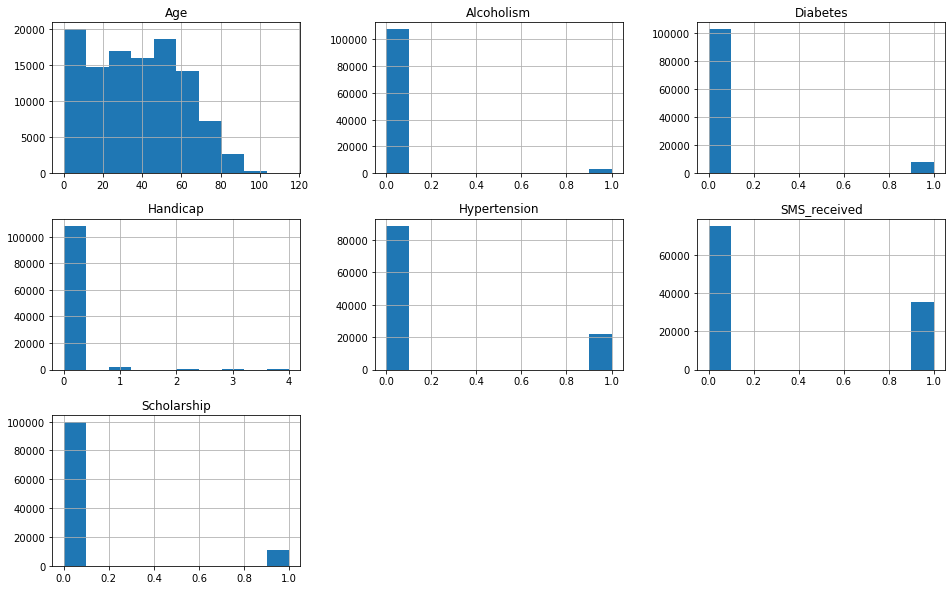

```python
# With Age being our dependent variable let's see it's relationship with the other columns
# First, getting a visyal representation of the data
data.hist(figsize = (16,10))
plt.show();
```

# Age:

There are more younger people in the data.

# Alcoholism:

Most of the patients are not alcoholics.

# Diabetes:

Most of the patients are not diabetes but more than alcoholics.

# Handicap:

# Hypertension:

Most patients do not have hypertension diagnosed but there are few patients being diagnosed with it.

# SMS_received:

Most of the patient didn't receive sms compared to those who receive.

# Functions

> Creating various functions to help with the plotting of graphs

```python
# A function to help visualize the number of occurrences of a category
def count_plot(df,xvar):
    sns.countplot(data=df,x=xvar)
    plt.title(f"Distribution of {xvar}".title(), weight ="bold")
    plt.xlabel(xvar.title(), weight = "bold")
    plt.ylabel("Frequency", weight = "bold")

# A function to help plot pie chart
def pie(x,labels):
    data[x].value_counts().plot(kind="pie", autopct="%1.2f%%", explode = [0,0.1], labels = labels)
    plt.title(f"Distribution of {x}".title(), weight ="bold")

# Knowing the percentage difference
def percent_diff(a,b):
    a=a
    b=b
    c=a + b
    d = a/c *100
    e = b/c *100
    print(f"The percentage difference of the distribution are {round(d)}% and {round(e)}%")
```

# Gender

```python
gender_data = data["Gender"].value_counts()
print(f"There are {gender_data.values[0]} females and {gender_data.values[1]} males in the dataset")
```

```
There are 71839 females and 38687 males in the dataset
```

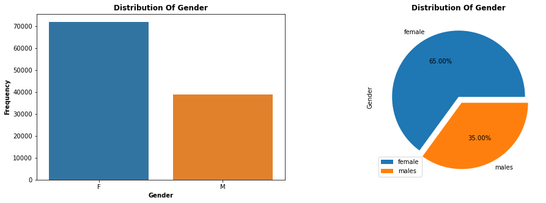

```python
# vizulizing the number of occurences for Gender
plt.figure(figsize=(16,5))
plt.subplot(121)
count_plot(data, "Gender")
plt.subplot(122)
pie("Gender",labels=["female", "males"])
plt.legend()
plt.show();
```

The number of females are clearly higher than the males in this data. The females are 71839 in number with a ratio of 65%, while the males are 38687 in number with a ratio of 35%.

# AGE

```python
data["Age"].describe()
```

```
count    110526.000000
mean         37.089219
std          23.110026
min           0.000000
25%          18.000000
50%          37.000000
75%          55.000000
max         115.000000
Name: Age, dtype: float64
```

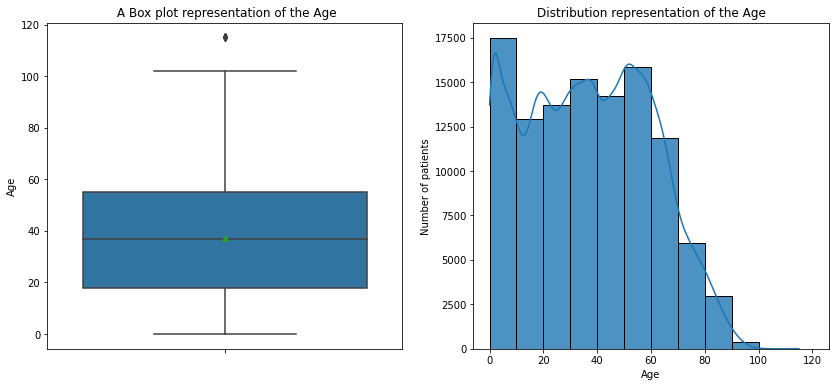

```python
# Plotting a graphical representation for age
plt.figure(figsize=(14,6))
plt.subplot(121)
sns.boxplot(y="Age", data=data, showmeans=True)
plt.title(" A Box plot representation of the Age");
plt.subplot(122)
sns.histplot(data=data,x="Age", multiple = "stack", bins=np.arange(0,130,10), alpha =0.8, kde=True)
plt.ylabel("Number of patients")
plt.title("Distribution representation of the Age");
```

# NO_SHOW

```python
# Knowing the number of people that didn't show and people who did.
no_show = data["No_show"].value_counts()
print(f"There are {no_show.values[0]} of people who didn't show and {no_show.values[1]} of people who showed.")
```

[output not shown]

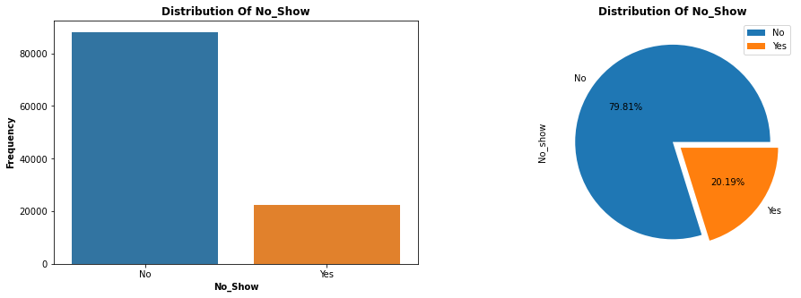

```python
# Trying to know the graphical representation of No_show
plt.figure(figsize=(16,5))
plt.subplot(121)
count_plot(data, "No_show")
plt.subplot(122)
pie("No_show", labels = ["No","Yes"])
plt.legend();
```

```python
data["No_show"].describe()
```

```
count     110526
unique         2
top           No
freq       88207
Name: No_show, dtype: object
```

# Scholarship

```python
# Knowing the amount of people who registered and people who didn't register
data_sch = data["Scholarship"].value_counts()
data_sch
print(f"There are {data_sch.values[0]} of people who don't have scholarship and {data_sch.values[1]} of people who have scholarship")
```

```
There are 99665 of people who don't have scholarship and 10861 of people who have scholarship
```

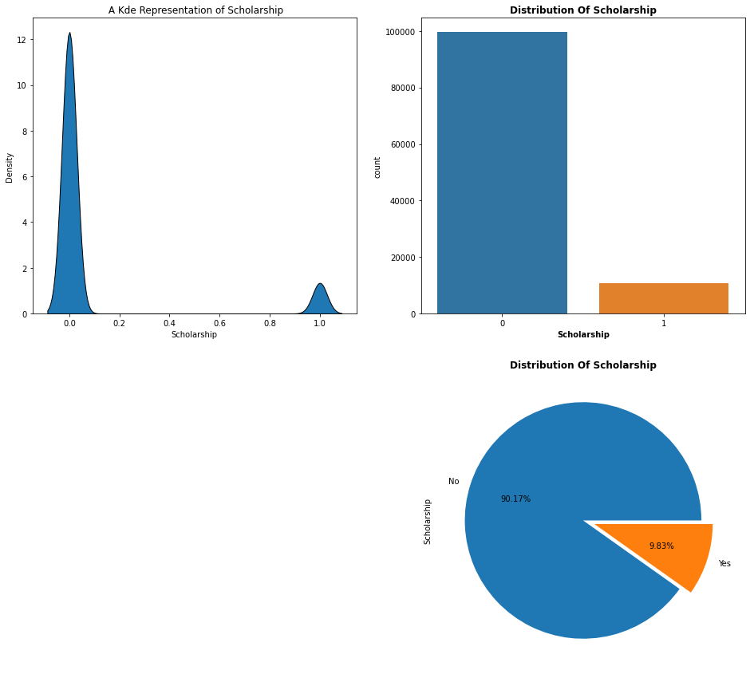

```python
# Graphical representation of people who have scholarship and people who don't
plt.figure(figsize=(16,15))
plt.subplot(2,2,1)
sns.kdeplot(data=data,x="Scholarship", multiple = "stack", alpha =1)
plt.title(" A Kde Representation of Scholarship")
plt.subplot(2,2,2)
count_plot(data, "Scholarship")
plt.subplot(2,2,4)
pie("Scholarship",labels=["No","Yes"])
plt.show()
```

```python
data["Scholarship"].describe()
```

```
count    110526.000000
mean          0.098266
std           0.297676
min           0.000000
25%           0.000000
50%           0.000000
75%           0.000000
max           1.000000
Name: Scholarship, dtype: float64
```

The percentage of people who enrolled in Brasilian welfare program Bolsa Família are very low, only 9.8% of patients are registered for the wellfare program.

# Hypertension

```python
# Knowing the number of people who have Hypertension and people who don't
hyper = data["Hypertension"].value_counts()
print(f"There are {hyper.values[1]} who are diagnosied with hypertension and {hyper.values[0]} who aren't")
```

```
There are 21801 who are diagnosied with hypertension and 88725 who aren't
```

```python
# Checking their percentage difference
percent_diff(21801,88725)
```

```
The percentage difference of the distribution are 20% and 80%
```

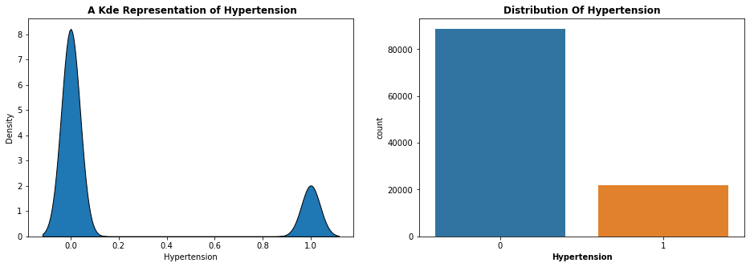

```python
# A graphical representation of Hypertension
plt.figure(figsize=(16,5))
plt.subplot(1,2,1)
sns.kdeplot(data=data,x="Hypertension", multiple = "stack", alpha =1)
plt.title(" A Kde Representation of Hypertension", weight = "bold")
plt.subplot(1,2,2)
count_plot(data,"Hypertension")
```

```python
data["Hypertension"].describe()
```

```
count    110526.000000
mean          0.197248
std           0.397923
min           0.000000
25%           0.000000
50%           0.000000
75%           0.000000
max           1.000000
Name: Hypertension, dtype: float64
```

From the over view there are little patient who have hypertension cause the percent of those who have are 20% against 80% of people don't have, aside from their percentage difference 75% of the fraction of the data don't have hypertension. It's safe to say that there are less patients with hypertension.

# Handicap

```python
print(f" There are {data.Handicap.nunique()} unique values which are: \n{data.Handicap.value_counts()}")
```

```
 There are 5 unique values which are:
0    108285
1      2042
2       183
3        13
4         3
Name: Handicap, dtype: int64
```

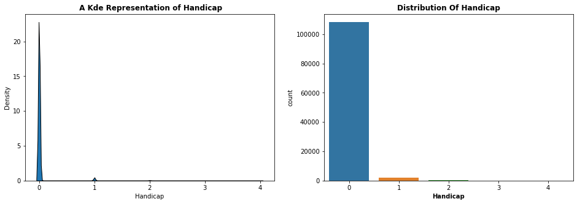

```python
plt.figure(figsize=(16,5))
plt.subplot(1,2,1)
sns.kdeplot(data=data,x="Handicap", multiple = "stack", alpha =1)
plt.title(" A Kde Representation of Handicap",weight = "bold")

plt.subplot(1,2,2)
count_plot(data,"Handicap")
```

```python
data["Handicap"].describe()
```

```
count    110526.000000
mean          0.022248
std           0.161543
min           0.000000
25%           0.000000
50%           0.000000
75%           0.000000
max           4.000000
Name: Handicap, dtype: float64
```

# SMS_received

```python
# Knowing the amount of people who received SMS and people who didn't
sms = data["SMS_received"].value_counts()
print(f"There are {sms.values[0]} who didn't receive any sms and {sms.values[1]} who receive")
```

```
There are 75044 who didn't receive any sms and 35482 who receive
```

```python
# Getting their percentage
percent_diff(75044,35482)
```

```
The percentage difference of the distribution are 68% and 32%
```

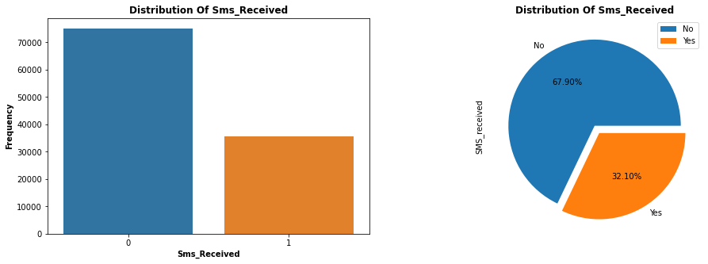

```python
plt.figure(figsize=(16,5))
plt.subplot(1,2,1)
count_plot(data,"SMS_received")
plt.subplot(1,2,2)
pie("SMS_received",labels = ["No", "Yes"])
plt.legend();
```

An overview shows that there were more people who didn't receive any SMS than people who did.

# Alcoholism

```python
# The number of alcoholic patients and non alcoholics
alcohol = data["Alcoholism"].value_counts()
print(f"There are {alcohol.values[0]} who aren't alcoholics and {alcohol.values[1]} who are")
```

```
There are 107166 who aren't alcoholics and 3360 who are
```

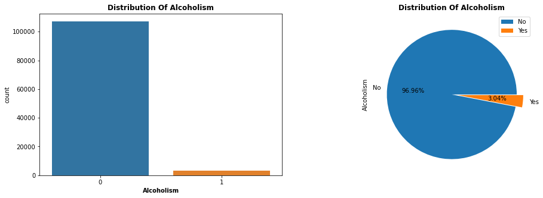

```python
plt.figure(figsize=(16,5))
plt.subplot(1,2,1)
count_plot(data,"Alcoholism")
plt.subplot(1,2,2)
pie("Alcoholism",labels = ["No", "Yes"])
plt.legend();
```

The percent of alcoholism here is very low compared to that of Hypertension